# Reproducible Research: Peer Assessment 1

## Loading and preprocessing the data

```r
activity <- read.csv("activity.csv")

#convert date format
activity$date <- as.Date(activity$date, format= "%Y-%m-%d")

#show header

head(activity)
```

```
##   steps       date interval
## 1    NA 2012-10-01        0
## 2    NA 2012-10-01        5
## 3    NA 2012-10-01       10
## 4    NA 2012-10-01       15
## 5    NA 2012-10-01       20
## 6    NA 2012-10-01       25
```

## What is mean total number of steps taken per day?

### 1. Calculate the total number of steps taken per day

```r
steps<- aggregate(activity$steps, by=list(activity$date), sum, na.rm=T)
```

### 2. Make a histogram of the total number of steps taken each day

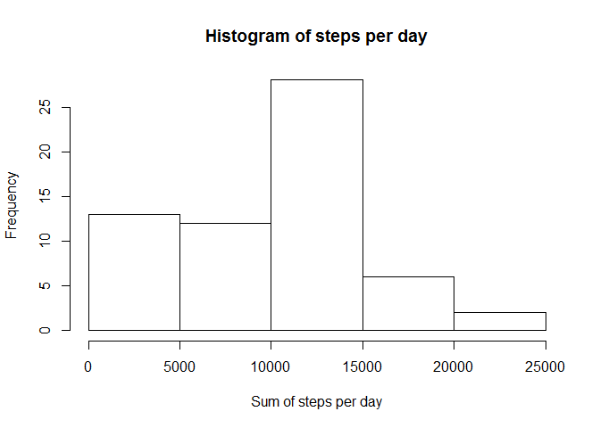

```r
hist(steps$x, xlab = "Sum of steps per day", main = "Histogram of steps per day")
```

### 3. Calculate and report the mean and median of the total number of steps taken per day

```r
mean_steps <- round(mean(steps$x))
print(c("The mean is",mean_steps))
```

```
## [1] "The mean is" "9354"
```

```r
median_steps <- round(median(steps$x))
print(c("The median is",median_steps))
```

```
## [1] "The median is" "10395"
```

## What is the average daily activity pattern?

### 1. Make a time series plot (i.e. type = “l”) of the 5-minute interval (x-axis) and the average number of steps taken, averaged across all days (y-axis)

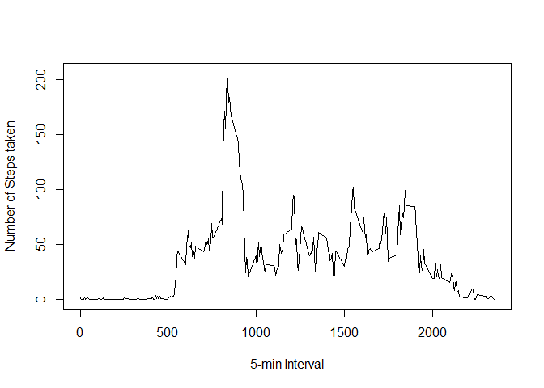

```r
mean_steps_int <- tapply(activity$steps, activity$interval, mean, na.rm=T)
plot(mean_steps_int ~ unique(activity$interval), type="l", xlab = "5-min Interval", ylab = "Number of Steps taken")
```

### 2. Which 5-minute interval, on average across all the days in the dataset, contains the maximum number of steps?

```r
max <- mean_steps_int[which.max(mean_steps_int)]

print(c("The max interval is",names(max)))
```

```
## [1] "The max interval is" "835"
```

## Imputing missing values

Note that there are a number of days/intervals where there are missing values (coded as NA). The presence of missing days may introduce bias into some calculations or summaries of the data.

### 1. Calculate and report the total number of missing values in the dataset (i.e. the total number of rows with NAs)

```r
activity_na <- sum(is.na(activity$steps))

print(c("total number of rows with NAs is",activity_na))
```

```
## [1] "total number of rows with NAs is" "2304"
```

### 2. Devise a strategy for filling in all of the missing values in the dataset.

**My strategy**: For any NA is the step variable, the mean number of steps (variable = **mean_steps_int**) of the corresponding interval is taken as the replacing value.

### 3. Create a new dataset that is equal to the original dataset but with the missing data filled in.

```r
activity2 <- activity
for (i in 1:nrow(activity)){
    if(is.na(activity$steps[i])==T){
        activity2$steps[i]<- mean_steps_int[[as.character(activity[i, "interval"])]]
    }
}
```

The following code tests that there are 0 NA values in **activity2**

```r
sum(is.na(activity2))
```

```
## [1] 0
```